# Statistical Rethinking by Richard McElreath

## Practice Questions

**easy 1.** Which of the expressions below correspond to the statement: the probability of rain on Monday?

answer: Pr(rain | Monday) and Pr(rain | Monday) / Pr(Monday)

**easy 2.** Which of the following statements corresponds to the expression: Pr(Monday|rain)?

answer: The probability that it is Monday, given that it is raining.

**easy 3.** Which of the expressions below correspond to the statement: the probability that it is Monday, given that it is raining?

answer: Pr(Monday | rain) and Pr(rain|Monday)*Pr(Monday)/Pr(rain)

the latter is due to Bayes rule *(need to derive this to make sure I understand)*

**easy 4.** What does it mean to say “the probability of water is 0.7”?

We believe that the true proportion of water on the globe is 0.7 (70%)

**medium 1.** Compute and plot the grid approximate posterior distribution for each of the following sets of observations. In each case, assume a uniform prior for p

1. W,W,W

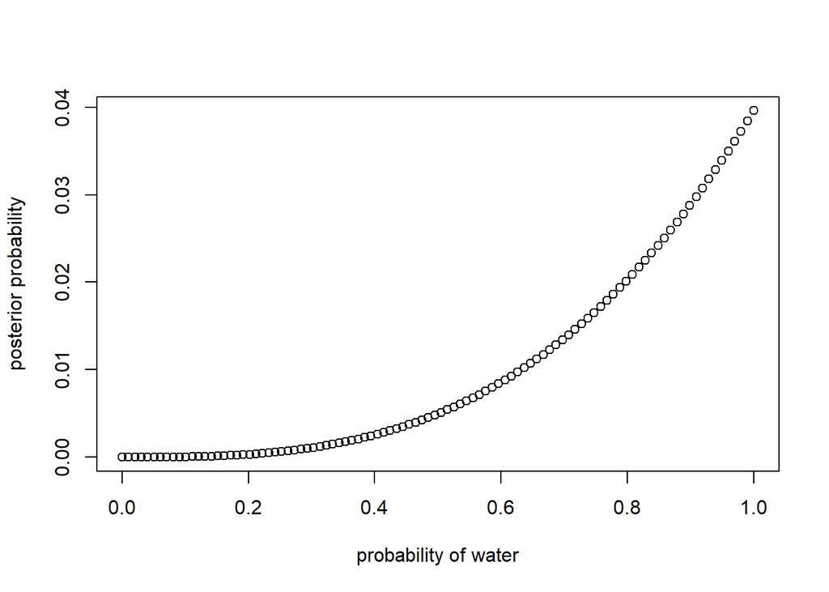

```r
# define grid
p_grid <- seq( from=0 , to=1 , length.out=100 )

# define prior
prior <- rep( 1 , 100 )

# compute likelihood at each value in grid
likelihood <- dbinom( 3 , size=3 , prob=p_grid )

# compute product of likelihood and prior
unstd.posterior <- likelihood * prior

# standardize the posterior, so it sums to 1
posterior <- unstd.posterior / sum(unstd.posterior)

plot( p_grid , posterior , type="b" ,
xlab="probability of water" , ylab="posterior probability" )
```

2. W,W,W,L

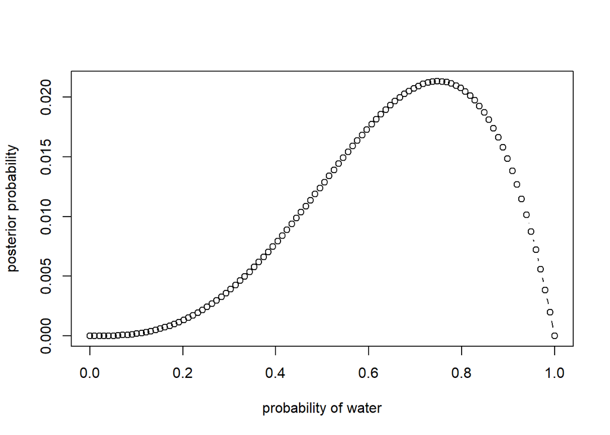

```r
# define grid
p_grid <- seq( from=0 , to=1 , length.out=100 )

# define prior
prior <- rep( 1 , 100 )

# compute likelihood at each value in grid
likelihood <- dbinom( 3 , size=4 , prob=p_grid )

# compute product of likelihood and prior
unstd.posterior <- likelihood * prior

# standardize the posterior, so it sums to 1
posterior <- unstd.posterior / sum(unstd.posterior)

plot( p_grid , posterior , type="b" ,
xlab="probability of water" , ylab="posterior probability" )
```

3. L, W, W, L, W, W, W

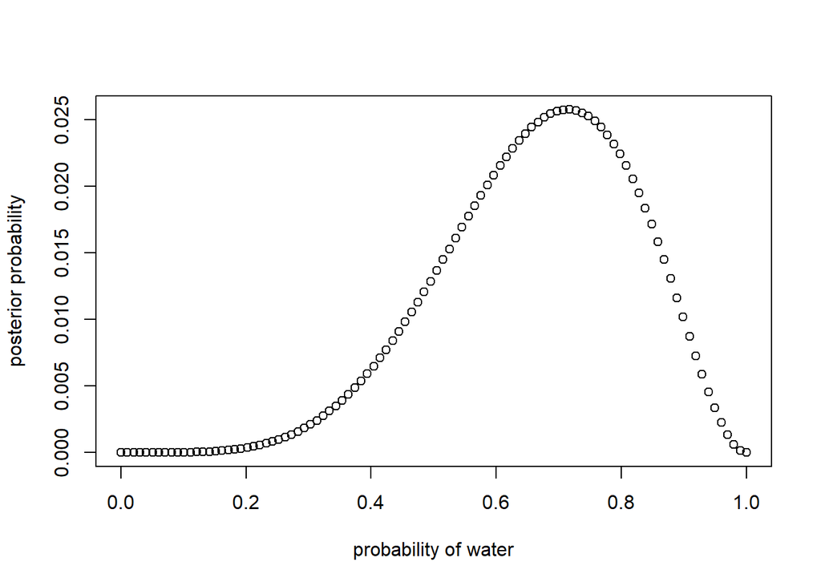

```r
# define grid
p_grid <- seq( from=0 , to=1 , length.out=100 )

# define prior
prior <- rep( 1 , 100 )

# compute likelihood at each value in grid
likelihood <- dbinom( 5 , size=7 , prob=p_grid )

# compute product of likelihood and prior
unstd.posterior <- likelihood * prior

# standardize the posterior, so it sums to 1
posterior <- unstd.posterior / sum(unstd.posterior)

plot( p_grid , posterior , type="b" ,
xlab="probability of water" , ylab="posterior probability" )
```

**Medium 2.** Now assume a prior for p that is equal to zero when p < 0.5 and is a positive constant when p ≥ 0.5. Again compute and plot the grid approximate posterior distribution for each of the sets of observations in the problem just above.

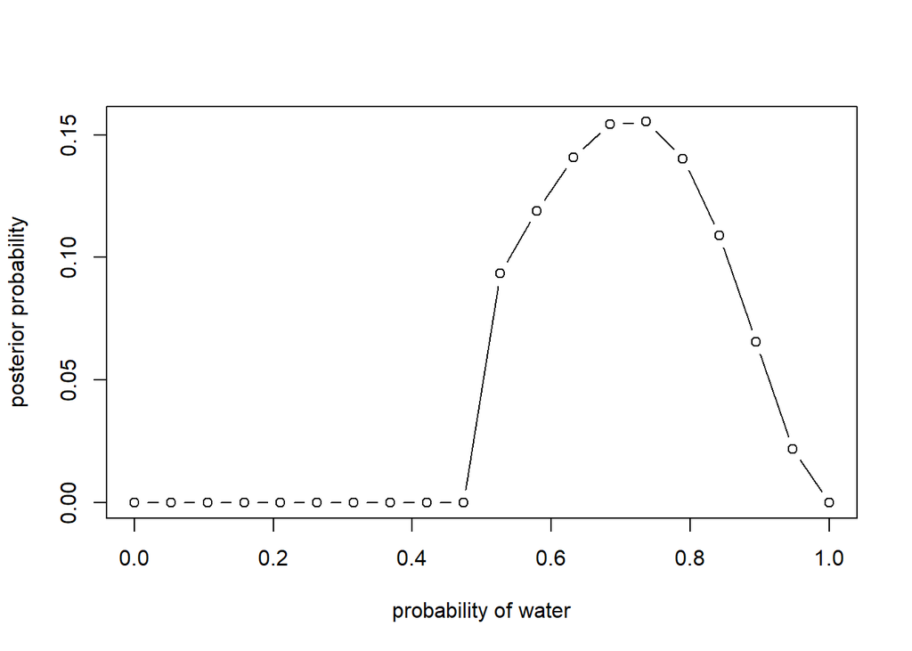

```r
# define grid
p_grid <- seq( from=0 , to=1 , length.out=20 )

# define prior
prior <- ifelse(p_grid < 0.5, 0, 1)

# compute likelihood at each value in grid
likelihood <- dbinom( 5 , size=7 , prob=p_grid )

# compute product of likelihood and prior
unstd.posterior <- likelihood * prior

# standardize the posterior, so it sums to 1
posterior <- unstd.posterior / sum(unstd.posterior)

plot( p_grid , posterior , type="b" ,
xlab="probability of water" , ylab="posterior probability" )
```

# Week Two: Geocentric Models / Wiggly Orbits

# Week Three: The Many Variables and The Spurious Waffles